# Bayes KCNQ1 Model Application

Matthew O’Neill

7/6/2022

# Introduction

This document describes our Bayesian penetrance estimation protocol for the KCNQ1-LQT1 genotype-phenotype relationship. We build the model based on observed heterozygote phenotypes and variant specific features, including function, structure, and in silico predictions.

In this RMD, we deploy these estimates to investigate variable penetrance among different channelopathies, compare Bayesian estimates to ClinVar annotations, export data for clinical and research use hosted at our Variant Browser, and export estimates to map onto structure.

# Model Construction

## Data from Literature and Cohort Combined

```r
# Literature dataset where potentially overlapping carriers/heterozygotes are removed
d <- lit.cohort.data[lit.cohort.data$mut_type == "missense",]

# set initial weighting and penetrance
d$weight = 1-1/(0.01+d$total_carriers)
d$penetrance_lqt1 <- d$lqt1/d$total_carriers
d[d$total_carriers < 1,"weight"] <- 0.000 # This is changed to "< 2" here to evaluate ROC-AUC of n=1 variants from the literature
```

## LQT1 empirical diagnosis probability prior

```r
# Mean squared error
mse <- function(sm) {
  mean((sm$residuals)^2*(sm$weights))
}

# Derive alpha and beta from weighted mean and MSE (estimated variance)
estBetaParams <- function(mu, var) {
  alpha <- ((1 - mu) / var - 1 / mu) * mu ^ 2
  beta <- alpha * (1 / mu - 1)
  return(params = list(alpha = alpha, beta = beta))
}

# Weighted mean to determine lqt1 penetrance empirical prior
newdata = data.frame(wt=1)
model <- lm(penetrance_lqt1 ~ 1, data=d, weights = d$weight)
summary(model)
```

```
##
## Call:
## lm(formula = penetrance_lqt1 ~ 1, data = d, weights = d$weight)
##
## Weighted Residuals:
##      Min       1Q   Median       3Q      Max
## -0.41731 -0.19483 -0.04157  0.06946  0.56486
##
## Coefficients:
##             Estimate Std. Error t value Pr(>|t|)
## (Intercept)  0.41777    0.01497    27.9   <2e-16 ***
## ---
## Signif. codes:  0 '***' 0.001 '**' 0.01 '*' 0.05 '.' 0.1 ' ' 1
##
## Residual standard error: 0.2563 on 629 degrees of freedom
```

```r
p<-predict(model, newdata)
dev<- mse(model) #p*(1-p)

# Estimated shape parameters for lqt1 empirical prior
alpha0 = estBetaParams(p,dev)$alpha
beta0 = estBetaParams(p,dev)$beta
print(paste("alpha0 = ", alpha0, "  beta0 = ", beta0))
```

```
## [1] "alpha0 =  1.13103115117603   beta0 =  1.57629587356151"
```

```r
# Bayesian lqt1 penetrance estimates from empirical priors
# and observed affected/unaffected counts:
d$lqt1_penetranceBayesian_initial <- (alpha0 + d[,"lqt1"])/((alpha0 + beta0 + d[,"total_carriers"]))
d$lqt1_penetranceBayesian<-d$lqt1_penetranceBayesian_initial
```

## Merge Clinical Dataframe with Covariate Dataframe

Work with 1 dataframe of all variant data

```r
q1.covariates <- distinct(q1.covariates, var, .keep_all = TRUE)
q1.covariates[is.na(q1.covariates$mut_type), "mut_type"] <- "missense"
d$resnum <- as.integer(d$resnum)
d <- merge(d, q1.covariates, all = TRUE)
d[is.na(d$total_carriers), "total_carriers"] <- 0
d <- unique(d)
```

## Calculate Bayesian priors and posteriors for all variants

Update the empirical posteriors to generate Bayesian priors and posteriors. Additional details available in the Supplemental Methods.

```r
# Assign p_mean_w to empirical penetrance. The reassignment to ensures
# p_mean_w does not contain "NA"s.
d[is.na(d$lqt1_penetranceBayesian),"lqt1_penetranceBayesian"] <- alpha0/(alpha0+beta0)
d$p_mean_w <- d$lqt1_penetranceBayesian

# reassign "NA"s to 0 in heterozygote counts to enable updating during EM iterations
d[is.na(d$total_carriers),"total_carriers"] <- 0
d[is.na(d$lqt1),"lqt1"] <- 0
d[is.na(d$unaff),"unaff"] <- 0

regression <- function(dv, pivs, nivs, data) {
  # run a linear model with text arguments for dv and ivs
  piv_string <- paste(pivs, collapse=" + ")
  niv_string <- paste(nivs, collapse=" - ")
  if(niv_string!="") iv_string <- paste(piv_string, " - ", niv_string, sep = "")
  if(niv_string=="") iv_string <- paste(piv_string)
  #print(iv_string)
  regression_formula <- as.formula(paste(dv, iv_string, sep=" ~ "))
  #print(regression_formula)
  glm(regression_formula, data, family = quasibinomial(link = "logit"), weights = data[,"weight"])
}

# solve for alpha and beta in Beta distribution
solab <- function(mean, variance){
  alpha <- (mean^2 * (1-mean) - variance * mean)/variance
  beta <- alpha * (1 / mean - 1)
  return(c(alpha,beta))
}

covariates <- c("blast_pssm", "revel_score", "cardiacboost", "hm_peak", "lqt1_dist")
delta <- 10
count <- 0
tmp<-d[!is.na(d$mut_type) & d$mut_type=="missense" & !is.na(d$lqt1_dist),]
while(delta > 1 & count < 25){ # 5 is roughly a change of 0.5%
  print(paste(delta, count))
  count <- count + 1
  alpha_f <- NULL
  beta_f <- NULL

  for(i in 1:nrow(tmp)){
  newdata = data.frame(var=tmp[i,"var"])
  newdata[covariates] <- tmp[i,covariates]
  model <- regression("p_mean_w", covariates,
                      colnames(newdata)[colSums(is.na(newdata))>0], tmp)
  mean_f <- predict(model, newdata, type = "response")
  variance_f <- (predict(model, newdata,se.fit = T, type = "response")$se.fit)^2
  alpha <- solab(mean_f,variance_f)[1]
  beta <- solab(mean_f,variance_f)[2]
  tmp[i,"prior_mean_w"] <- mean_f
  if(alpha<0.01 | beta<0.01){
    alpha_f[i]=alpha0
    beta_f[i]=beta0
  }else{
    alpha_f[i]=alpha
    beta_f[i]=beta
  }
  }
  new_mean <- (alpha_f + tmp$lqt1)/(alpha_f + beta_f + tmp$total_carriers)

  delta <- sum(abs(new_mean-tmp$p_mean_w))

  tmp$p_mean_w <- new_mean
  print(delta)
}

for (variant in tmp$var){t<-NA;t<-tmp[tmp$var == variant, c("prior_mean_w", "p_mean_w")]; d[d$var == variant, c("prior_mean_w", "p_mean_w")] <- t[1,] }

for (variant in mut_type$var){print(variant);
  if (!is.na(match(variant,d$var)) & !is.na(match(variant, lit.cohort.data$var))) {
    d[d$var == variant, c("lqt1", "unaff","total_carriers")]<-lit.cohort.data[lit.cohort.data$var == variant, c("lqt1", "unaff","total_carriers")] # removed "gnomAD","gnomAD_seq"
    }
}

# when tuning parameter is 11, equivalent to 10 variant heterozygotes

prior_mean <- d$p_mean_w
variance <- prior_mean*(1-prior_mean)
variance <- variance / 11
ind_a <- seq(1, length(variance),1)
ind_b <- seq(length(variance)+1, length(variance)*2,1)
alpha <- solab(prior_mean,variance)[ind_a]
beta <- solab(prior_mean,variance)[ind_b]

new_mean <- (alpha + d$lqt1)/(alpha + beta + d$total_carriers)
d$p_mean_w <- new_mean
d$prior_mean <- (alpha)/(alpha + beta)
d[d$total_carriers<1,"p_mean_w"]<-d[d$total_carriers<1,"prior_mean_w"]

d$alpha <- alpha
d$beta <- beta

# Save literature data for all variants
# save as regular vs evalset depending on LQT1 dist method!
save(d,file = "lit_plus_cohort_checkpoint_application.RData")
```

# Penetrance Histograms

Here we construct the penetrance histograms that are shown in Figure 3 of the manuscript. We look at observed and Bayesian penetrance, highlighting the shortcomings of using observed penetrance when only few heterozygotes are clinically ascertained.

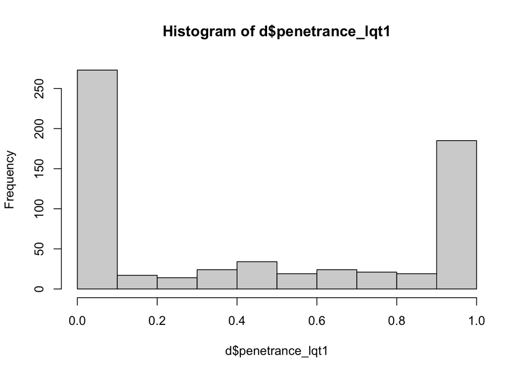

```r
# Produce histograms for Figure 3 - take only variants with observed heterozygotes

d <- d[d$total_carriers >0, ]
hist(d$penetrance_lqt1)
```

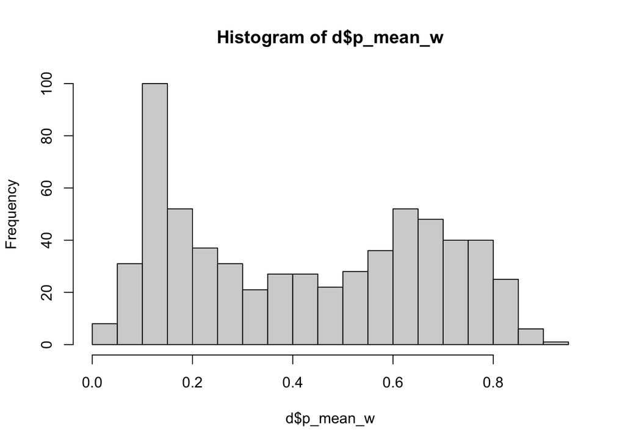

```r
hist(d$p_mean_w, breaks = 20)
```

```r
quantile(d$p_mean_w)
```

```
##          0%         25%         50%         75%        100%
## 0.002475638 0.170276600 0.419484669 0.652836109 0.902504924
```

# Variant Browser Data

Here we generate the data that are used in our online variantbrowser.org - this site contains the complete dataset for all variants in an interactive format.

```r
# Here we output data to be hosted on the variant browser to facilitate research and clinical applications
# Reload data after last analysis

rm(d)
load('RMD and Scripts/lit_plus_cohort_checkpoint_application.RData')

# annotate structural location (hotspot)

d$Structure<-NA
d[!is.na(d$lqt1_dist) & d$lqt1_dist<0.1,"Structure"]<-"Non_Hotspot"
d[!is.na(d$lqt1_dist) & d$lqt1_dist>=0.1 & d$lqt1_dist<0.4,"Structure"]<-"Mild_Hotspot"
d[!is.na(d$lqt1_dist) & d$lqt1_dist>=0.4,"Structure"]<-"Hotspot"

# annotate functional perturbation

d$Function<-NA
d[!is.na(d$ht_peak) & d$ht_peak<0.25,"Function"]<-"Severe Dominant LOF"
d[!is.na(d$ht_peak) & d$ht_peak<0.5 & d$ht_peak>=0.25,"Function"]<-"Dominant LOF"
d[!is.na(d$ht_peak) & d$ht_peak>=0.5 & d$ht_peak<0.75,"Function"]<-"LOF"
d[!is.na(d$ht_peak) & d$ht_peak>=0.75 & d$ht_peak<1.25,"Function"]<-"Normal"
d[!is.na(d$ht_peak) & d$ht_peak>=1.25,"Function"]<-"GOF"

data <- d

# Use CardiacBoost dataframe for merging genomic coordinates with each variant

cb<-read.table('Covariates/cardiacboost_arm_all_possible_mutations-adj.csv', sep = "\t", header = TRUE)
cb<-cb[cb$gene=="KCNQ1",]
cb$var<-as.character(paste(cb$var))
cb_cDNA <- cb[,c("var", "HGVSc", "pos")]
final_data <- merge(data, cb_cDNA, by.x = "var", all = TRUE)
var_browser_q1 <- final_data[,c("pos", "HGVSc", "var", "resnum", "lqt1", "total_carriers", "Function", "Structure", "p_mean_w")]
var_browser_q1 <- var_browser_q1[complete.cases(var_browser_q1$HGVSc), ]
write.csv(var_browser_q1, "variant_browser_v2.csv")
var_browser_in_silico <- final_data[,c("var", "provean_score", "revel_score", "blast_pssm", "pph2_prob", "lqt1_dist")]
var_browser_in_silico <- var_browser_in_silico[complete.cases(var_browser_in_silico$revel_score), ]
write.csv(var_browser_in_silico, "var_browser_in_silico.csv")
```

#ClinVar Analysis We comparte categorical penetrance of variants among ClinVar categories with the Bayesian penetrance estiamtes derived from our method. This analysis highlights the high degree of incomplete penetrance, even among Pathogenic-annotated ClinVar variants.

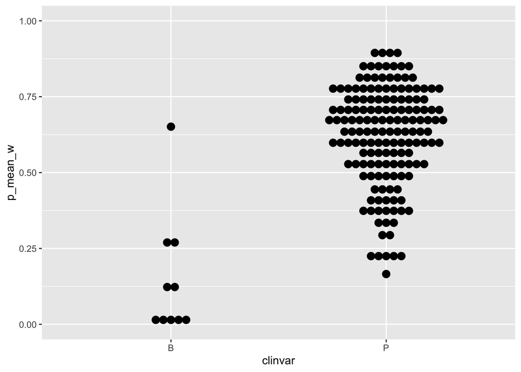

```r
# Reload data after last analysis
rm(d)
load('RMD and Scripts/lit_plus_cohort_checkpoint_application.RData')

# Here we compare the observed and Bayesian penetrance against ClinVar annotations as presented in Figure 4

annotation <- read.csv('Heterozygote Data/KCNQ1_clinvar.csv', header = TRUE)
d2 <- data.frame(annotation)
d3 <- merge(d, d2, by = "var")
d3 <- d3[, c("clinvar", "p_mean_w", "penetrance_lqt1")]

# Plot Bayesian penetrence
ggplot(d3, aes(x = clinvar, y = p_mean_w)) + geom_dotplot(binaxis='y', stackdir='center', dotsize = 0.75) + ylim(0, 1)
```

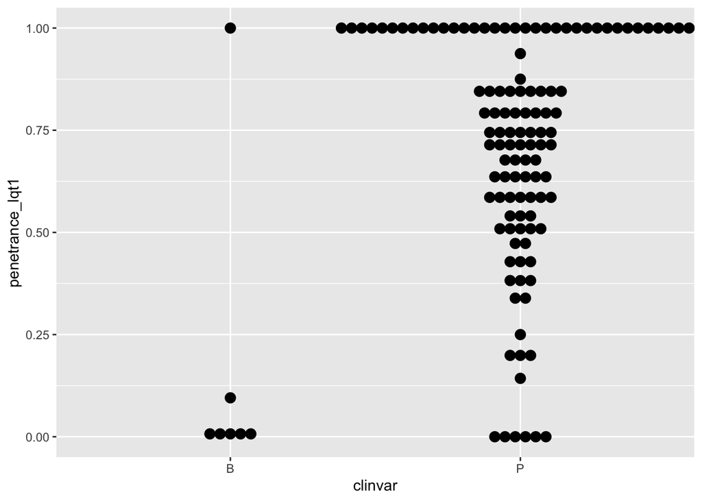

```r
# Plot observed penetrence
ggplot(d3, aes(x = clinvar, y = penetrance_lqt1)) + geom_dotplot(binaxis='y', stackdir='center', dotsize = 0.75) + ylim(0, 1)
```

# Structural Penetrance Data

Here we generate a dataframe that is used in our structural analyses. The weights of these per-variant outputs are used to differentially color the protein structure, and highlight regions of high estimated penetrance. These analyses can help provide insight into structural-determinants of penetrance.

```r
# Generate .csv for pymol sessions to model LQT1 penetrance on protein structure as shown in Figure 5

rm(d)
load('RMD and Scripts/lit_plus_cohort_checkpoint_application.RData')

structure_penetrance <- d
structure_penetrance <- structure_penetrance[,c("var", "resnum", "p_mean_w")]
```

# Forest Plots

We generate forest plots for all possible variants in KCNQ1, as well as for a specific example shown in the Figure 2 of the manuscript. These highlight the ability of clinical phenotypes to further refine Bayesian prior estimates, tailoring the point estimate and decreasing its associated uncertainty.

```r
# Make forest plots for prospective use and for Figure 2B
rm(d)
load('RMD and Scripts/lit_plus_cohort_checkpoint_application.RData')

library(forestplot)
d<-d[d$total_carriers>0 & d$mut_type!="nonsense",]
d<-d[!is.na(d$var),]

mean.post <- (d$alpha + d$lqt1)/(d$alpha+d$beta+d$total_carriers)
mean.prior <- (d$alpha)/(d$alpha+d$beta)

lower.prior <- qbeta(0.025,d$alpha,d$beta)
higher.prior <- qbeta(0.975,d$alpha,d$beta)

lower.post <- qbeta(0.025,d$alpha+d$lqt1,d$beta+d$total_carriers-d$lqt1)
higher.post <- qbeta(0.975,d$alpha+d$lqt1,d$beta+d$total_carriers-d$lqt1)

forest.data.post <- data.frame(variant = d$var, mean=mean.post,
                          lower=lower.post, higher=higher.post, resnum=d$resnum, tc=d$total_carriers, lqt1=d$lqt1)
forest.data.post$group<-"posterior"

forest.data.prior <- data.frame(variant = d$var, mean=mean.prior,
                          lower=lower.prior, higher=higher.prior, resnum=d$resnum, tc=d$total_carriers, lqt1=d$lqt1)
forest.data.prior$group<-"prior"

### Break here for Figure specific script!

forest.data<-rbind(forest.data.post, forest.data.prior)
forest.data<-forest.data[order(forest.data$resnum, forest.data$variant),]
forest.data$label<-""
forest.data[forest.data$group=="posterior","label"]<-paste(forest.data[forest.data$group=="posterior","lqt1"], "/", forest.data[forest.data$group=="posterior","tc"])

#define colours for dots and bars
dotCOLS = c("#866D4B","#000000")
barCOLS = c("#FFFFFF","#FFFFFF")

plotg <- function(a,b){
  fd<-forest.data[a:b,]
  png( paste('RMD and Scripts/images/Forest plot', a, "-",b,"pics.png",sep=""),res=300,height=10,width=10,units="in")
  p<-ggplot(fd, aes(x=reorder(variant,-resnum), y=mean, ymin=lower, ymax=higher, col=group, fill=group)) +
  geom_text(data=fd, aes(x=reorder(variant,-resnum), label=label)) +
#specify position here
  geom_linerange(size=2,position=position_dodge(width = 1)) +
  geom_hline(yintercept=1, lty=1) +
  geom_hline(yintercept=0, lty=1) +
#specify position here too
  geom_point(size=2, shape=21, colour="white", stroke = 0.5,position=position_dodge(width = 1)) +
  scale_fill_manual(values=barCOLS)+
  scale_color_manual(values=dotCOLS)+
  scale_y_continuous(name="LQT1 Diagnosis Probability", limits = c(0, 1)) +
  coord_flip() +
  theme_minimal()
  print(p)
  dev.off()
}

sapply(0:30*50+1,function(x) plotg(x,x+49))
```

[output not shown]